# Лабораторная работа 5

## Объединение ячеек в строке и изменение формата записи

**multicolumn** - принимает три аргумента: 1. Количество ячеек, которые должны быть объединены 2. Выравнивание объединенной ячейки 3. Содержимое объединенной ячейки

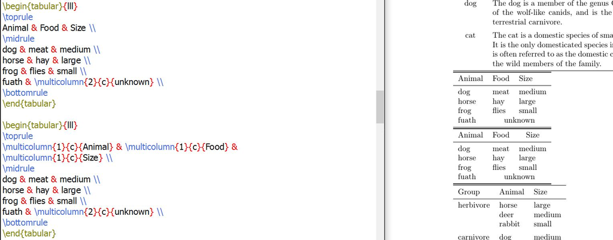

объединение ячеек в строке и изменение формата записи

## Объединение столбцов

В LaTex не предусмотрены функции для объединения столбцов.

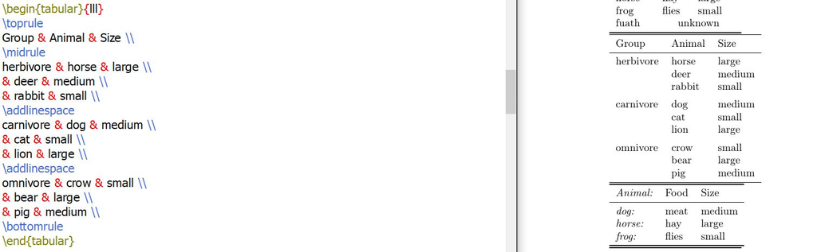

объединение столбцов

## Запись курсивом и дополнительные знаки

Поскольку > и < могут использоваться для размещения вещей перед и после содержимого ячейки столбца, вы можете использовать их для добавления команд, которые влияют на внешний вид столбца.

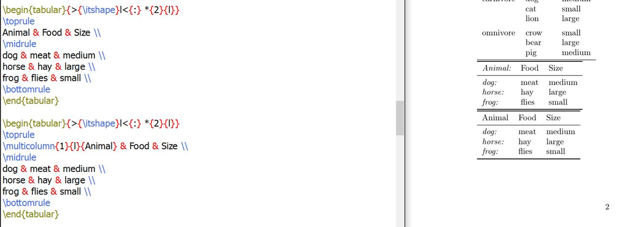

как записать курсивом и добавить дополнительные знаки

## Добавление расстояния между столбцами

Пространство между стоблцами можно заменить на что-то произвольное, используя @. Токен ! делает что-то довольно похожее. А | в свою очередь похоже на !{decl}.

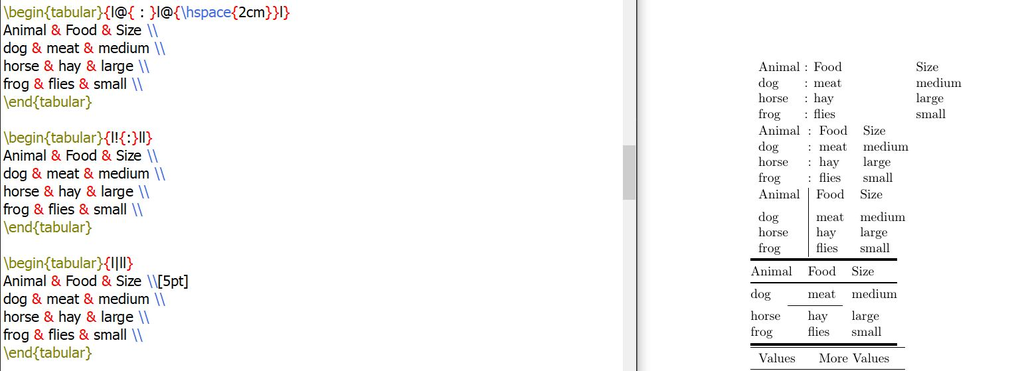

добавление расстояния между столбцами

## Изменение толщины границ

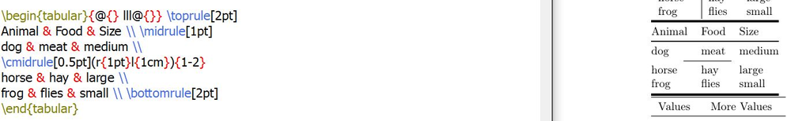

изменение толщины границ

## Таблицы с численными значниями

Необходимо ввести пакет siunitx.

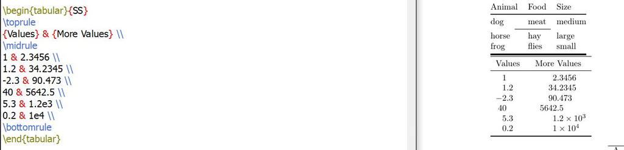

таблицы с численными значниями

## tabular и tabularx

**Tabular** — базовое окружение, которое позволяет определить структуру таблицы, указав количество столбцов и их форматирование.

**Tabularx** — расширение стандартной таблицы tabular с автоматическим расчётом ширины колонок. У таблицы можно указать общую ширину (первый параметр). Автоматически вычисляемая колонка обозначается как X. Текст в таких колонках автоматически переносится.

## tabular и tabularx

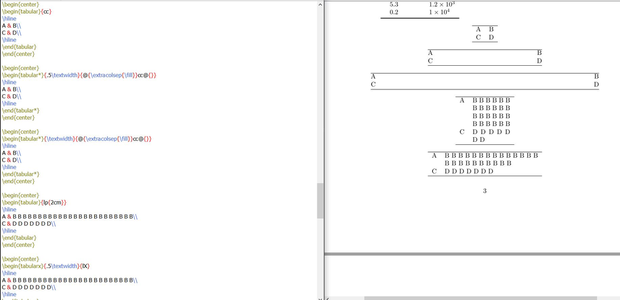

tabular и tabularx

## Многостраничные таблицы

Для их записи необходимо ввести пакет **longtable**.

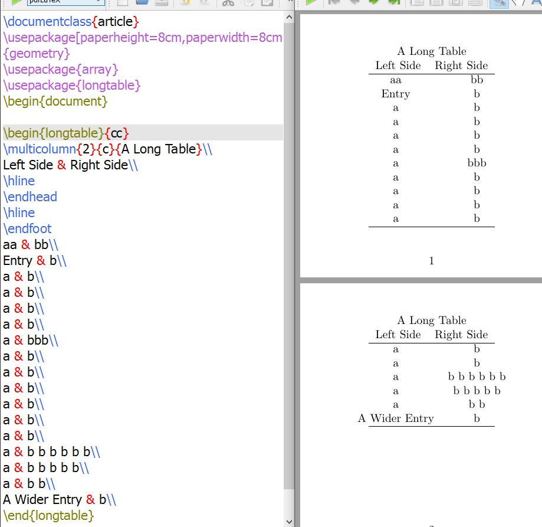

многостраничные таблицы

## Ссылки в таблице

Для их записи необходимо ввести пакет **threeparttable**. Сам формат записи можно видеть на изображении ниже.

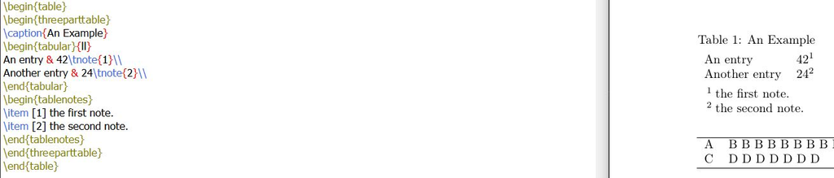

ссылки в таблице

## Вёрстка в узких колонках

Настройки разбиения строк по умолчанию предполагают относительно длинные строки, чтобы обеспечить некоторую гибкость в выборе разбиений строк. Следующий пример показывает некоторые возможные подходы. Первая таблица показывает растянутое межсловное пространство, и TeX предупреждает о недостаточно полных строках. Использование **raggedright** обычно избегает этой проблемы, но может оставить некоторые строки «слишком рваными». Команда **RaggedRight** из пакета **ragged2e** является компромиссом; она допускает некоторую рваность в длине строк, но также будет переносить слова, где это необходимо, как показано в третьей таблице. Обратите внимание на использование **arraybackslash** здесь, которое сбрасывает определение \ так, чтобы оно завершало строку таблицы. Альтернативная техника, как показано в четвертой таблице, заключается в использовании меньшего шрифта, чтобы колонки не были такими узкими относительно размера текста.

## Вёрстка в узких колонках

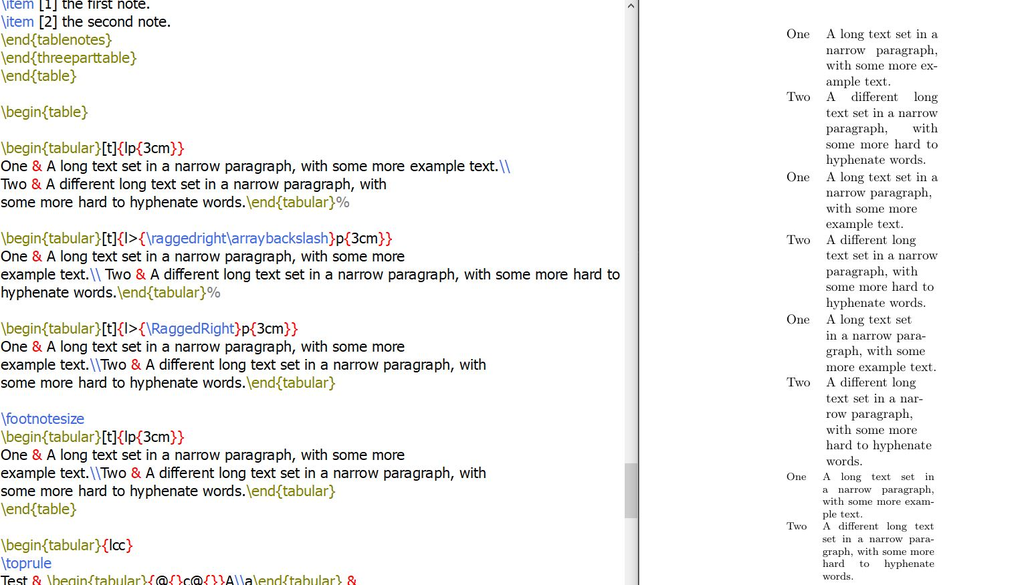

вёрстка в узких колонках

## Вертикальные трюки

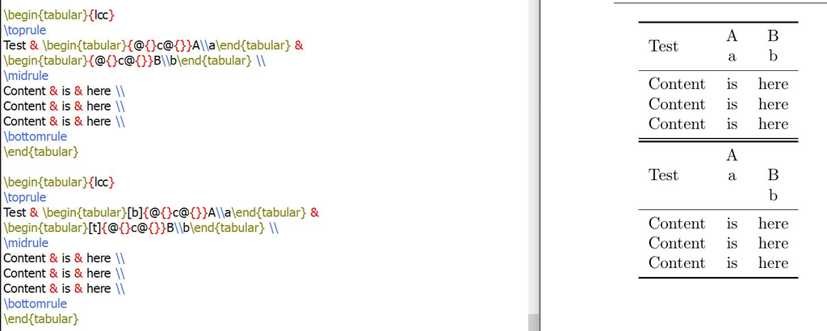

вертикальные трюки

## Изменение межстрочного интервала

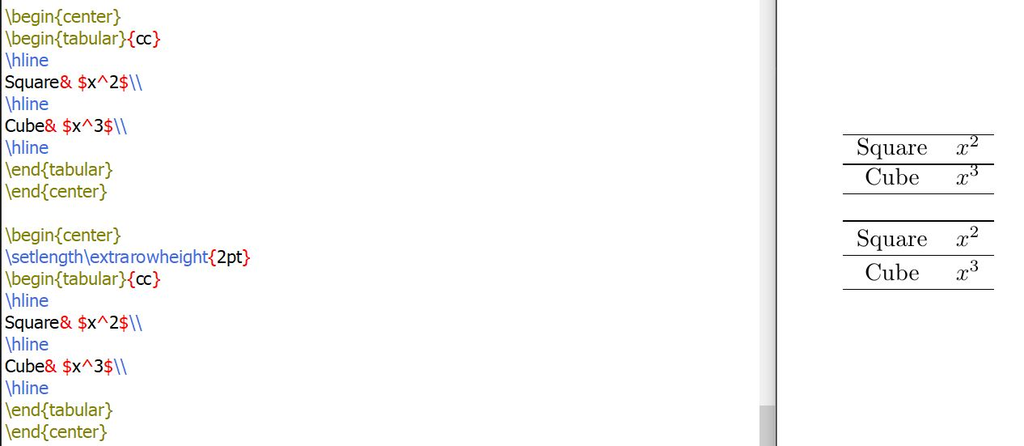

изменение межстрочного интервала

## Выводы

В процессе выполнения данной лабораторной работы я научилась добавлять и редактировать таблицы в среде LaTex.

Спасибо за внимание!